# Имитационное моделирование

## 5.4 Шаг 4. Запуск модели SIR

Выполняем скрипт `sir_ode.jl` командой `include("scripts/sir_ode.jl")` из Julia REPL. Скрипт содержит определение правой части системы ОДУ (уравнения 1–3):

```julia
function sir_ode!(du, u, p, t)
    (S, I, R) = u
    (beta, c, gamma) = p
    N = S + I + R
    @inbounds begin
        du[1] = -beta * c * I / N * S
        du[2] =  beta * c * I / N * S - gamma * I
        du[3] =  gamma * I
    end
    nothing
end
```

На рис. 5 представлен вывод скрипта с результатами расчёта.

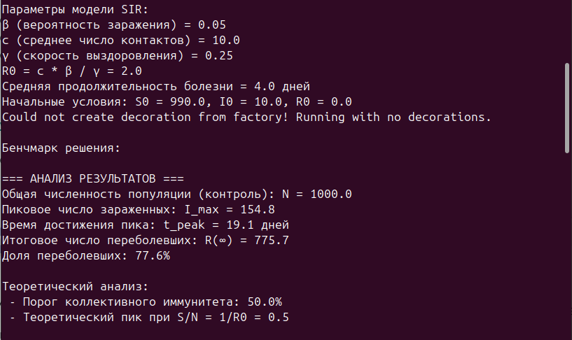

Рисунок 5: Параметры и результаты моделирования SIR

Из вывода (рис. 5) следует:

- $R_0 = c \cdot \beta / \gamma = 10 \cdot 0.05 / 0.25 = 2.0$ — эпидемия распространяется;
- средняя продолжительность болезни $1/\gamma = 4$ дня;
- пиковое число заражённых $I_{\max} = 154.8$ человека достигается на $t = 19.1$ день;
- итоговое число переболевших $R(\infty) = 775.7$, что составляет 77.6% популяции;
- порог коллективного иммунитета — 50%;
- теоретический пик наступает при $S/N = 1/R_0 = 0.5$.

Скрипт строит семь графиков: основную динамику $S(t)$, $I(t)$, $R(t)$; кривую заражённых с отметкой пика; логарифмический масштаб $I(t)$; доли населения в процентах; фазовый портрет $I$ vs $S$; динамику эффективного репродуктивного числа $R_e(t)$; а также сводную панель из шести подграфиков.

Сводная панель результатов модели SIR приведена на рис. 6.

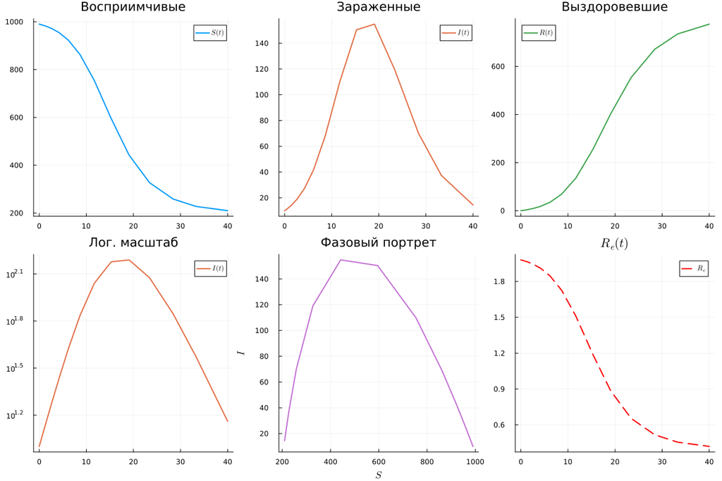

На рис. 6 отчётливо видна характерная колоколообразная кривая заражённых с пиком на 19-й день, S-образный рост числа выздоровевших и момент, когда $R_e(t)$ опускается ниже единицы — после этого эпидемия входит в фазу спада.

Основной график динамики трёх компартментов отображён на рис. 7.

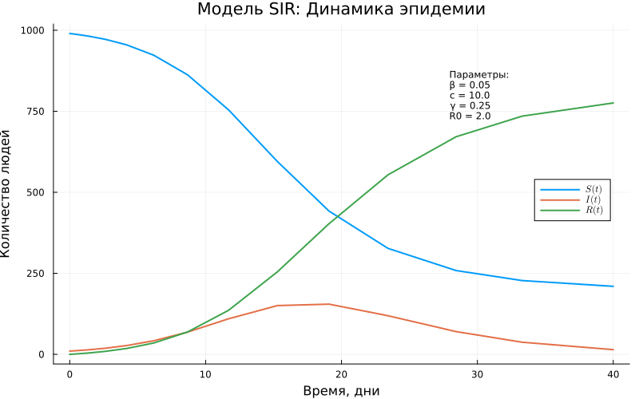

Рисунок 7: Модель SIR: динамика эпидемии — кривые $S(t)$, $I(t)$, $R(t)$ с аннотацией параметров

Кривая заражённых $I(t)$ с отмеченным пиком эпидемии представлена на рис. 8.

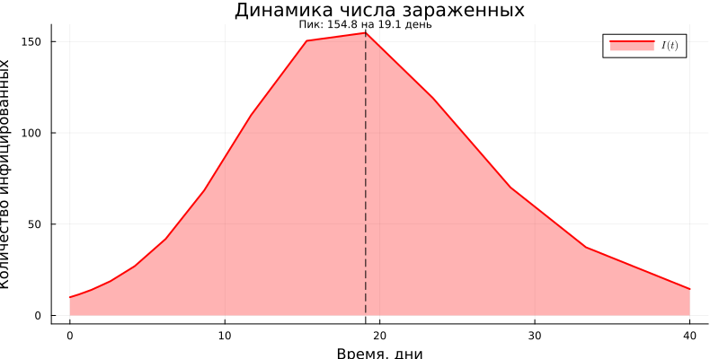

Рисунок 8: Динамика числа заражённых $I(t)$ с вертикальной отметкой пика ($I_{\max} = 154.8$ на день 19.1)

На рис. 9 построена та же кривая $I(t)$ в логарифмическом масштабе, что позволяет оценить экспоненциальный характер начальной фазы роста.

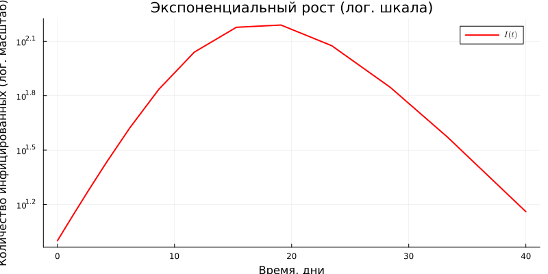

Рисунок 9: Экспоненциальный рост числа заражённых (логарифмическая шкала)

Доли населения в каждом компартменте с горизонтальной линией порога коллективного иммунитета показаны на рис. 10.

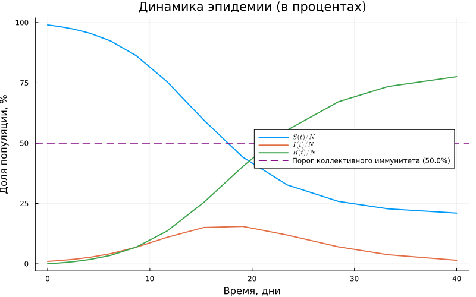

Рисунок 10: Динамика эпидемии в процентах с порогом коллективного иммунитета (50%)

Фазовый портрет модели SIR ($I$ vs $S$) со стрелками направления движения на рис. 11.

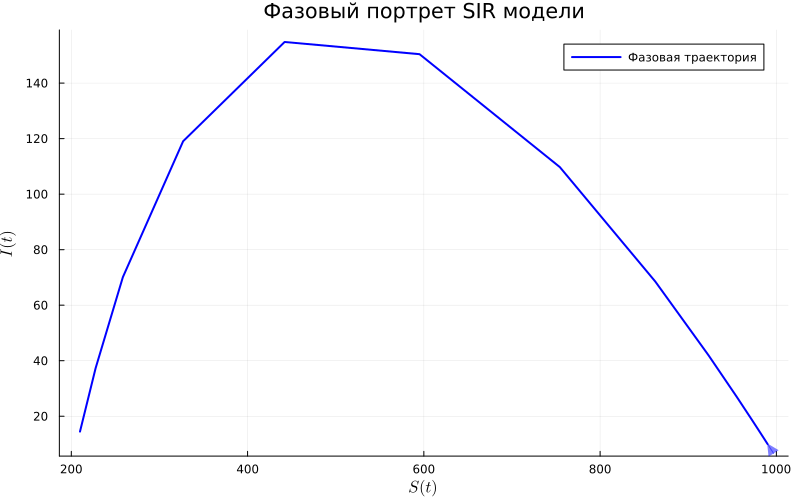

Рисунок 11: Фазовый портрет модели SIR (плоскость $S$–$I$)

Динамика эффективного репродуктивного числа $R_e(t)$ с горизонтальной линией порога $R_e = 1$ приведена на рис. 12.

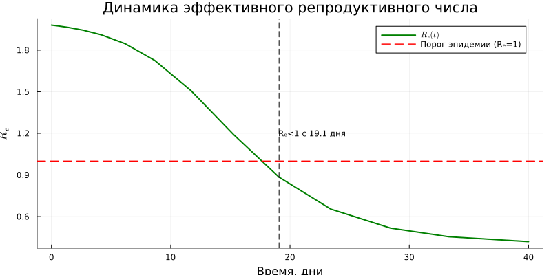

Рисунок 12: Динамика эффективного репродуктивного числа $R_e(t)$: пересечение порога $R_e = 1$ означает начало спада эпидемии

## 5.5 Шаг 5. Запуск модели Лотки–Вольтерры

Аналогично запускаем скрипт `lv_ode.jl` командой `include("scripts/lv_ode.jl")`. Правая часть системы ОДУ (уравнения 5–6) реализована следующим образом:

```julia
function lotka_volterra!(du, u, p, t)
    x, y = u
    alpha, beta, delta, gamma = p
    @inbounds begin
        du[1] = alpha * x - beta * x * y
        du[2] = delta * x * y - gamma * y
    end
    nothing
end
```

Решение находится методом Tsit5 (Рунге–Кутты 5-го порядка с адаптивным шагом) на интервале $t \in [0, 200]$ с начальными условиями $x_0 = 40$ (жертвы), $y_0 = 9$ (хищники).

Вывод скрипта с результатами расчёта представлен на рис. 13.

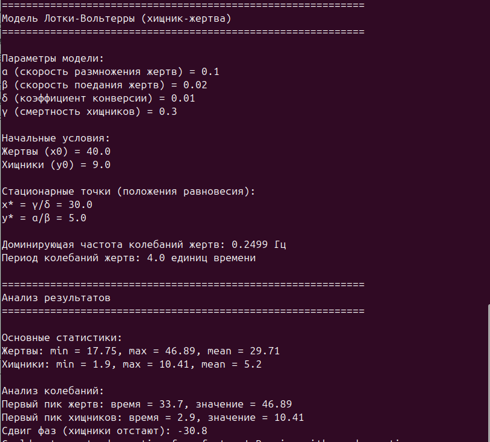

Рисунок 13: Параметры и результаты моделирования Лотки–Вольтерры

Скрипт строит шесть графиков: динамику популяций, фазовый портрет с изоклинами и стационарной точкой, производные (скорости изменения), относительные темпы роста, спектральный анализ (FFT) и сводную панель.

Сводная панель результатов модели Лотки–Вольтерры приведена на рис. 14.

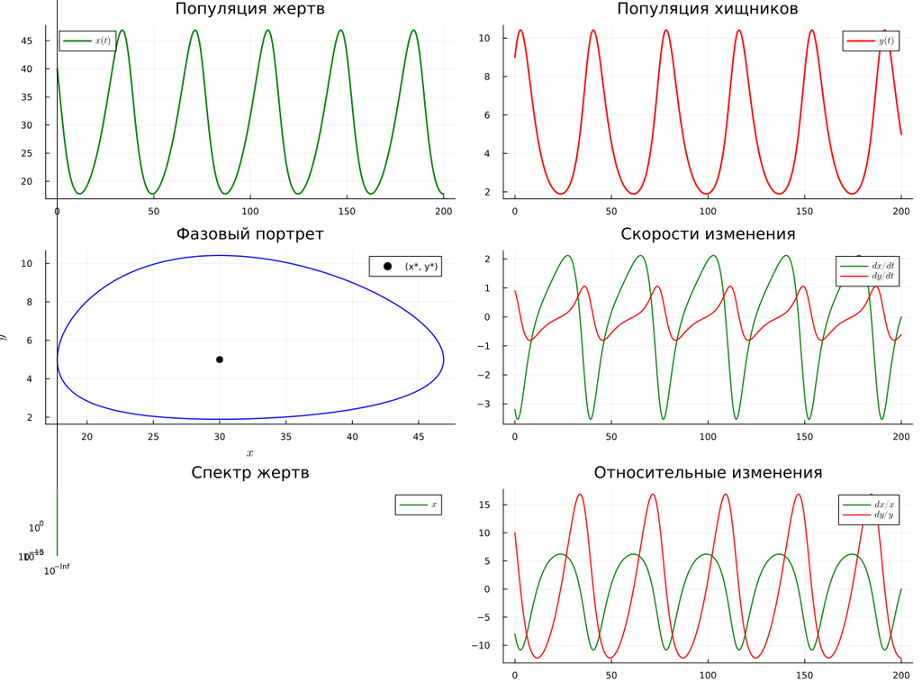

Рисунок 14: Сводная панель модели Лотки–Вольтерры: динамика популяций, фазовый портрет, скорости изменения, спектр FFT и относительные изменения

Динамика популяций жертв и хищников со стационарными уровнями на рис. 15.

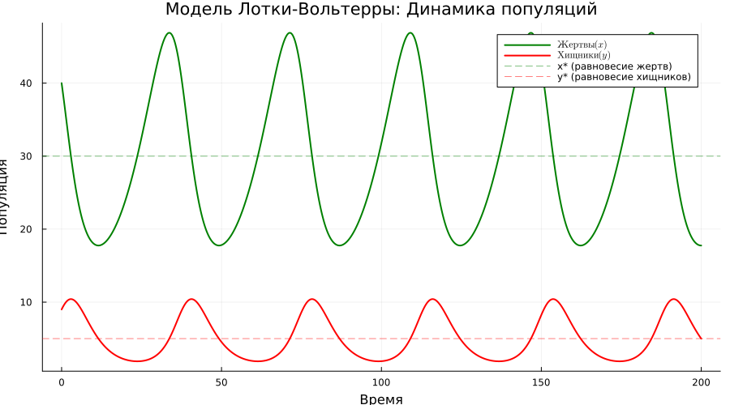

Рисунок 15: Динамика популяций жертв $x(t)$ и хищников $y(t)$ с горизонтальными линиями равновесных значений

Фазовый портрет системы с изоклинами, стационарной точкой и стрелками направления движения — рис. 16.

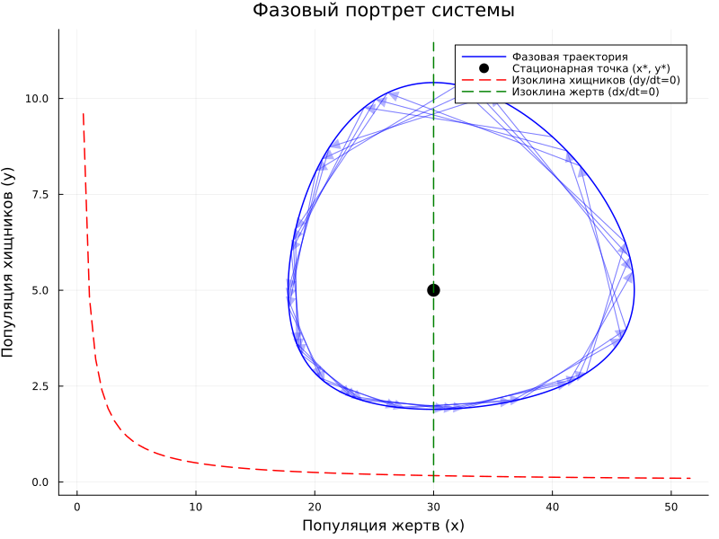

Рисунок 16: Фазовый портрет модели Лотки–Вольтерры: замкнутая орбита, изоклины и стационарная точка $(x^*, y^*) = (30, 5)$

Скорости изменения (производные) обеих популяций на рис. 17.

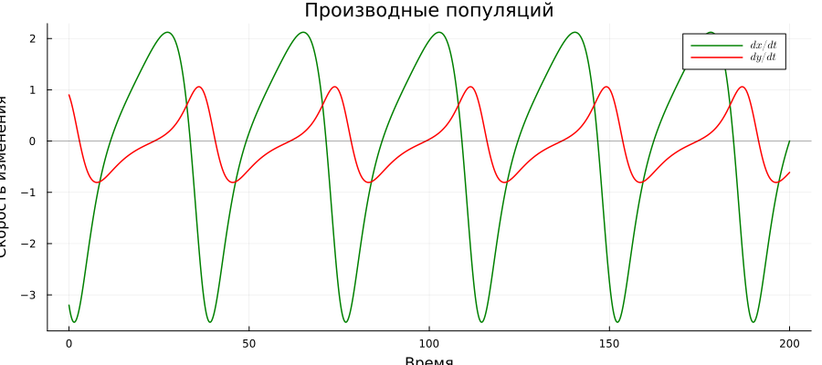

Рисунок 17: Производные популяций $dx/dt$ и $dy/dt$: осцилляции скоростей с характерным сдвигом фаз

Относительные темпы роста в процентах на рис. 18.

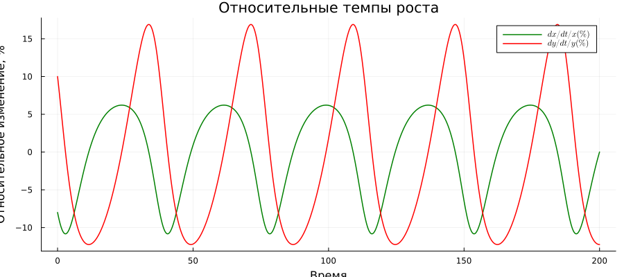

Рисунок 18: Относительные темпы роста $(dx/dt)/x$ и $(dy/dt)/y$ в процентах

Спектральный анализ (быстрое преобразование Фурье) колебаний популяции жертв на рис. 19.

[figure not shown]

## 5.6 Шаг 6. Преобразование кода в литературный стиль

После того как оба скрипта успешно выполнены и результаты верифицированы, переходим к ключевому этапу — преобразованию рабочего кода в литературный стиль. Концепция литературного программирования [1] предполагает, что программа пишется в первую очередь для человека, а не для машины.

В каждый скрипт добавляется разметка Literate.jl (см. табл. 1): текстовые пояснения с формулами LaTeX записываются в комментариях (`# Текст`), директивы `#jl` и `#nb` управляют включением фрагментов в конкретные форматы. Сам код модели при этом остаётся идентичным — добавляются лишь текстовые пояснения и условные директивы.

Для модели SIR литературный скрипт начинается с развёрнутого теоретического блока:

```julia
# # Модель SIR (эпидемиологическая модель)
#
# Стандартная compartmental-модель распространения инфекционного
# заболевания в однородной закрытой популяции.
#
# ## Теоретические основы
#
# Население делится на три компартмента:
# - **S** (*Susceptible*) --- восприимчивые к заражению;
# - **I** (*Infectious*) --- инфицированные и заразные;
# - **R** (*Recovered*) --- выздоровевшие и иммунные.
#
# Система ОДУ:
# $$\frac{dS}{dt} = -\frac{\beta c I}{N} S$$
# $$\frac{dI}{dt} = \frac{\beta c I}{N} S - \gamma I$$
# $$\frac{dR}{dt} = \gamma I$$
```

Аналогично создаётся литературная версия для модели Лотки–Вольтерры с описанием экологического контекста, уравнений и таблицы параметров.

## 5.7 Шаг 7. Генерация Markdown-документации

Подключаем пакет Literate.jl (рис. 20) и генерируем Markdown-документацию из обоих скриптов.

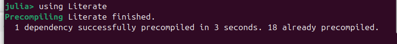

Рисунок 20: Загрузка пакета Literate (предварительная компиляция)

Вызываем `Literate.markdown()` для генерации `.md`-файлов. Для модели SIR результат показан на рис. 21.

```julia
Literate.markdown(scriptsdir("sir_ode.jl"), "docs")
```

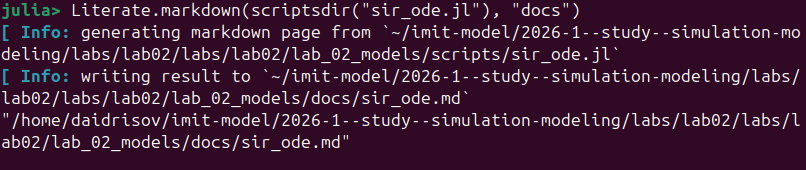

Рисунок 21: Генерация Markdown-документации `sir_ode.md` из литературного скрипта SIR

Literate.jl берёт исходный скрипт, превращает комментарии в текст Markdown, а код — в оформленные кодовые блоки. В консоли видно: исходник взят из `scripts/sir_ode.jl`, результат записан в `docs/sir_ode.md`.

Аналогично генерируется документация для модели Лотки–Вольтерры (рис. 22):

```julia
Literate.markdown(scriptsdir("lv_ode.jl"), "docs")
```

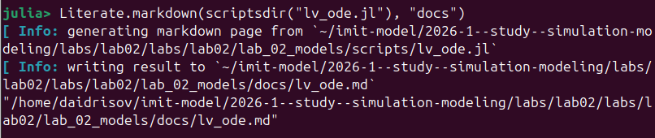

Рисунок 22: Генерация Markdown-документации `lv_ode.md` из литературного скрипта Лотки–Вольтерры

## 5.8 Шаг 8. Генерация Jupyter Notebooks

Далее генерируем Jupyter notebooks из тех же литературных скриптов. Вызываем `Literate.notebook()`:

```julia
Literate.notebook(scriptsdir("sir_ode.jl"), "notebooks")
Literate.notebook(scriptsdir("lv_ode.jl"), "notebooks")
```

Результат генерации ноутбука SIR показан на рис. 23: в консоли видно, что создан файл `sir_ode.ipynb` в каталоге `notebooks/`.

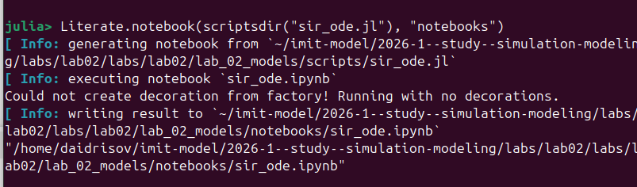

Рисунок 23: Генерация Jupyter notebook `sir_ode.ipynb`

Аналогично для модели Лотки–Вольтерры (рис. 24):

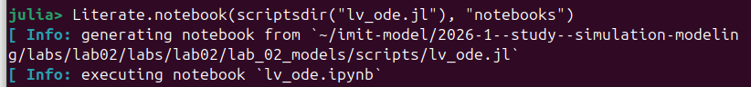

Рисунок 24: Генерация Jupyter notebook `lv_ode.ipynb`

Итоговая структура сгенерированных файлов:

Таблица 4: Производные форматы, сгенерированные из литературных скриптов

| Формат | Файлы | Каталог |
| --- | --- | --- |
| Markdown-документация | `sir_ode.md`, `lv_ode.md` | `docs/` |
| Jupyter notebook | `sir_ode.ipynb`, `lv_ode.ipynb` | `notebooks/` |

## 5.9 Шаг 9. Выполнение Jupyter Notebooks

Запускаем выполнение обоих ноутбуков через утилиту `jupyter nbconvert` из терминала (рис. 25):

```bash
~/.julia/conda/3/x86_64/bin/jupyter nbconvert \
    --to notebook --execute \
    --ExecutePreprocessor.kernel_name=julia-1.12 \
    --ExecutePreprocessor.timeout=1800 \
    --inplace notebooks/lv_ode.ipynb

~/.julia/conda/3/x86_64/bin/jupyter nbconvert \
    --to notebook --execute \
    --ExecutePreprocessor.kernel_name=julia-1.12 \
    --ExecutePreprocessor.timeout=1800 \
    --inplace notebooks/sir_ode.ipynb
```

Параметры команды:

- `--to notebook --execute` — выполнить ноутбук и записать результаты обратно;
- `--ExecutePreprocessor.kernel_name=julia-1.12` — явное указание ядра Julia;
- `--ExecutePreprocessor.timeout=1800` — таймаут 30 минут (при первом запуске компиляция пакетов занимает значительное время);
- `--inplace` — результаты записываются в тот же файл.

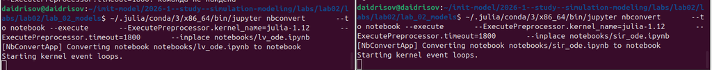

Рисунок 25: Параллельное выполнение обоих Jupyter notebooks через `jupyter nbconvert`

На рис. 26 видно успешное завершение: в файл `lv_ode.ipynb` записано 2194343 байта, в `sir_ode.ipynb` — 2847355 байт. Значительный объём объясняется встроенными графиками в формате PNG.

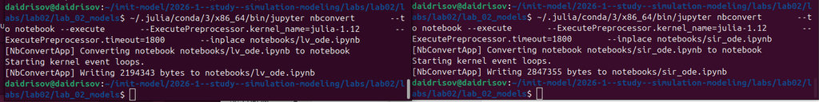

Рисунок 26: Успешное завершение выполнения обоих ноутбуков: данные записаны в файлы

## 5.10 Шаг 10. Добавление анализа чувствительности и перегенерация

Согласно заданию, в литературные скрипты добавляется раздел с анализом чувствительности — вычисление моделей для нескольких наборов параметров.

Для модели SIR варьируется параметр $\beta$ при фиксированных $c = 10$ и $\gamma = 0.25$, что позволяет получить значения $R_0$ от 0.5 до 4.0:

```julia
param_sets_sir = [
    (label="R0=0.5",  beta=0.0125, c=10.0, gamma=0.25),
    (label="R0=1.0",  beta=0.0250, c=10.0, gamma=0.25),
    (label="R0=2.0",  beta=0.0500, c=10.0, gamma=0.25),
    (label="R0=3.0",  beta=0.0750, c=10.0, gamma=0.25),
    (label="R0=4.0",  beta=0.1000, c=10.0, gamma=0.25),
]
```

Для модели Лотки–Вольтерры рассматриваются четыре сценария:

```julia
param_sets_lv = [
    (label="Базовый",             alpha=0.10, beta=0.02, delta=0.01, gamma=0.30),
    (label="Быстрый прирост жертв", alpha=0.20, beta=0.02, delta=0.01, gamma=0.30),
    (label="Усиленное хищничество", alpha=0.10, beta=0.04, delta=0.01, gamma=0.30),
    (label="Высокая выживаемость",  alpha=0.10, beta=0.02, delta=0.01, gamma=0.15),
]
```

```julia
Literate.markdown(scriptsdir("sir_ode.jl"), "docs")
Literate.markdown(scriptsdir("lv_ode.jl"), "docs")
```

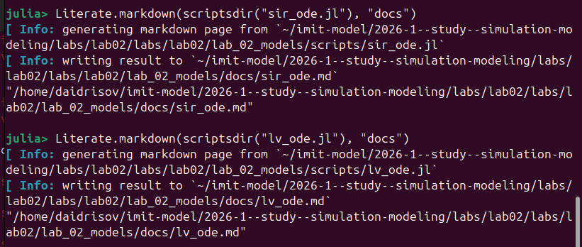

Рисунок 27: Перегенерация Markdown-документации после добавления анализа чувствительности

На рис. 27 видно, что документация обоих скриптов обновлена — теперь файлы `sir_ode.md` и `lv_ode.md` содержат разделы с анализом чувствительности.

## 5.11 Шаг 11. Интеграция Quarto-документации в отчёт

Завершающий этап — интеграция сгенерированной документации и графиков в настоящий отчёт. Графики, сохранённые скриптами в каталог `plots/`, вставляются в `.qmd`-файл по ссылкам. Ключевые фрагменты кода цитируются в блоках, результаты описываются с привязкой к конкретным числовым значениям.

Quarto обеспечивает:

- автоматическую нумерацию рисунков, таблиц и формул;
- перекрёстные ссылки (например, `[@fig-sir-panel]`, `[@eq-sir-s]`);
- библиографию в формате ГОСТ через CSL-стиль;
- рендеринг в PDF (через LaTeX) и DOCX.

# 6 Выводы

По итогам лабораторной работы удалось на практике освоить методологию литературного программирования и убедиться в её полезности для организации воспроизводимых научных вычислений.

Был создан проект DrWatson `lab_02_models` со стандартной структурой каталогов и набором зависимостей. Реализованы два скрипта моделирования — для модели SIR и модели Лотки–Вольтерры, — результаты которых верифицированы аналитически.

# Список литературы

1.

Knuth D. E. Literate Programming // The Computer Journal. 1984. Т. 27, № 2. С. 97–111.

2.

Schulte E. и др. A Multi-Language Computing Environment for Literate Programming and Reproducible Research // Journal of Statistical Software. 2012. Т. 46, № 3. С. 1–24.

3.

Kery M. B. и др. The Story in the Notebook: Exploratory Data Science using a Literate Programming Tool // Proceedings of the 2018 CHI Conference on Human Factors in Computing Systems. 2018. С. 1–11.

4.

Kermack W. O., McKendrick A. G. A Contribution to the Mathematical Theory of Epidemics // Proceedings of the Royal Society of London. Series A. 1927. Т. 115, № 772. С. 700–721.

5.

Hethcote H. W. The Mathematics of Infectious Diseases // SIAM Review. 2000. Т. 42, № 4. С. 599–653.

6.

Lotka A. J. Elements of Physical Biology. Baltimore: Williams; Wilkins, 1925.

7.

Volterra V. Variations and Fluctuations of the Number of Individuals in Animal Species Living Together // ICES Journal of Marine Science. 1928. Т. 3, № 1. С. 3–51.

8.

Rackauckas C., Nie Q. DifferentialEquations.jl — A Performant and Feature-Rich Ecosystem for Solving Differential Equations in Julia // Journal of Open Research Software. 2017. Т. 5, № 1. С. 15.

9.

Bezanson J. и др. Julia: A Fresh Approach to Numerical Computing // SIAM Review. 2017. Т. 59, № 1. С. 65–98.